[figure not shown]

# 01a - Correlations (15min)

1. Biological Motivation
2. Dataset
3. Summary Statistics
4. Correlations
5. Visualising Data
6. Comments

## 1. Biological motivation

You have been given a dataset of transcript levels (e.g. RNAseq, microarray, qRT-PCR) for two genes in your organism of interest. These transcript levels have been measured over 11 timepoints. You would like to know whether those genes are coregulated or not.

[figure not shown]

### QUESTION: (2min)

**How can you determine whether two genes are coregulated from transcript data?**

**What is the distinction between coregulation and *correlated expression*?** </div>

## 2. Dataset

**The `Code` cell below contains Python code that will load your dataset.**

You will have been assigned a letter: **A**, **B**, **C**, or **D** as part of the workshop. Please enter this letter in the first line of Python code, so that you are working with the appropriate dataset:

```
# Define your group, for this exercise
mygroup = "A"  # <- change the letter in quotes
```

and then *execute the cell* with `Ctrl-Enter` or `Shift-Enter`. This will load the exercise data into a *variable* called `data`.

```python
# Define your group, for this exercise
mygroup = "A"  # <- change the letter in quotes

# Import Python libraries
import os               # This lets us interact with the operating system
import pandas as pd     # This allows us to use dataframes
import seaborn as sns   # This gives us pretty graphics options

# Load the data
datafile = os.path.join('data', 'correlations', mygroup, 'expn.tab')
data = pd.read_csv(datafile, sep="\t")

# Show the first few lines of the data
data.head()
```

|  | gene1 | gene2 |
| --- | --- | --- |
| 0 | 10 | 8.04 |
| 1 | 8 | 6.95 |
| 2 | 13 | 7.58 |
| 3 | 9 | 8.81 |
| 4 | 11 | 8.33 |

After executing the `code` cell, you should see a table of values. The table has columns named **gene1** and **gene2**, and rows that are *indexed* starting at zero (it is typical in many programming languages to start counting at zero).

## 3. Summary statistics

**It can be very useful to get a quantitative overview of a new dataset by looking at some *bulk statistics*: the dataset's *mean*, *median*, *variance*, *standard deviation*, and minimum and maximum values.**

The data you loaded is in a `dataframe` (this behaves very much like `dataframe`s in the `R` language), and you can obtain summary statistics quite readily using the `.describe()` *method*.

```
# Show summary statistics of the dataframe
data.describe()
```

**Use the `.describe()` method to obtain summary statistics for your data in the cell below**

```python
# Show summary statistics of the dataframe
data.describe()
```

|  | gene1 | gene2 |
| --- | --- | --- |
| count | 11.000000 | 11.000000 |
| mean | 9.000000 | 7.500909 |
| std | 3.316625 | 2.031568 |
| min | 4.000000 | 4.260000 |
| 25% | 6.500000 | 6.315000 |
| 50% | 9.000000 | 7.580000 |
| 75% | 11.500000 | 8.570000 |
| max | 14.000000 | 10.840000 |

## 4. Correlations

**We have decided that, as a way of identifying potentially coregulated genes, we will lok for *correlated expression* between `gene1` and `gene2`**

The `dataframe` provides another *method* that reports the (Pearson) correlation coefficient between the columns of the dataset:

```
# Show the Pearson correlation coefficients between columns in the dataset
data.corr()
```

**Use the `.corr()` method to obtain summary statistics for your data in the cell below**

```python
# Show the Pearson correlation coefficients between columns in the dataset
data.corr()
```

|  | gene1 | gene2 |
| --- | --- | --- |
| gene1 | 1.000000 | 0.816421 |
| gene2 | 0.816421 | 1.000000 |

You can now make a quantitative estimate of whether these two genes are likely to be coregulated.

[figure not shown]

### QUESTION: (2min)

**How strong do you think the evidence is that these two genes are coregulated?**

## 5. Visualising Data

The `dataframe` provides a group of methods that allow us to plot the data for **gene1** and **gene2** in various ways. You will use the `.plot.scatter()` method in the cell below to visualise the way in which their transcript levels vary together.

**Use the `.plot.scatter()` method to visualise your data in the cell below**

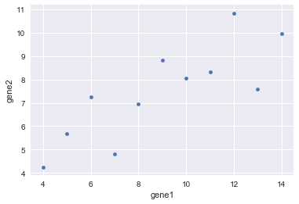

```python
# The line below allows plots to be rendered in the notebook
# This is very useful for literate programming, and for producing reports
%pylab inline

# Show a scatter plot of transcript levels for gene1 and gene2
data.plot.scatter('gene1', 'gene2');
```

[figure not shown]

### QUESTION: (2min)

**How strong do you think the evidence is that these two genes are coregulated?**

## 6. Comments

### 1. Always Visualise Your Data

Although your summary statistics looked promising (strong Pearson correlation coefficient), in some cases you will have seen that this single *point value* was misleading. You should always try to visualise your data in an appropriate way, so that you are not led astray by a single simple statstic (such as a *P*-value).

### 2. Correlation Does Not Imply Causation

[figure not shown]

This relationship has Pearson correlation coefficient of [**0.993**](http://tylervigen.com/view_correlation?id=1703)

### 3. In a Large Dataset, If You Look For Anything, You Will Find Something

[figure not shown]